# TITANIC SHIPWRECK : Machine Learning from Disaster

## Step 2: Bivariate Analysis

To find the relation between 2 variables we need to perform bivariate analysis.

Different methods are used to tackle different combinations during analysis process-

1. Continuous & Continuous
2. Categorical & Categorical
3. Continuous & Categorical

#### Continuous & Continuous

SCATTER PLOT - FIND OUT THE RELATIONSHIP B/W 2 VARIABLES BUT DOES NOT INDICATE THE STRENGTH OF RELATIONSHIP AMONGST THEM.

HEAT MAP - CORRELATION (TO FIND THE STRENGTH OF THE RELATIONSHIP, WE USE CORRELATION AMONG NUMERICAL VALUES)

(+1 POSITIVE LINEAR CORRELATION,-1 NEGATIVE LINEAR CORRELATION & 0 IS NO CORRELATION)

THE RELATIONSHIP CAN BE LINEAR OR NON LINEAR

#### Categorical & Categorical

STACKED BAR PLOT - THIS METHOD IS THE MOST VISUAL FORM OF 2 WAY TABLE

COUNT PLOT - SAME LIKE BAR PLOT

TWO WAY TABLE - TABLE COUNT & COUNT% BOTH ROW & COLUMN REPRESENT CATEGORY OF THEIR RESPECTIVE VARIABLES.

CHI-SQUARE TEST (TO TEST RELATIONSHIP BETWEEN VARIABLES)

If H0 (Null-Hypothesis) is fail to reject it means no relationship b/w variables and variables are independent.

#### Continuous & Categorical

WHILE EXPLORING RELATIONSHIP B/W CATEGORICAL & CONTINUOUS VARIABLES, WE CAN USE CAT PLOTS.

#### SCATTER PLOT & CORRELATION FOR NUMERICAL VALUES

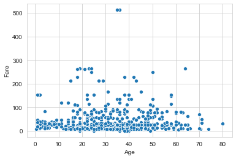

```python
sns.scatterplot(x='Age',y='Fare',data=titanic)
```

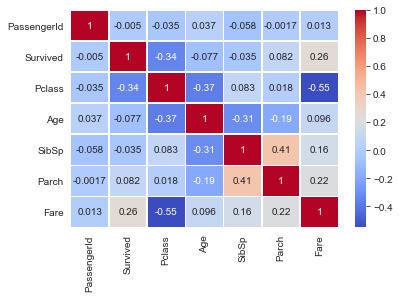

```python
sns.heatmap(titanic.corr(), annot=True, linewidth=0.5, cmap='coolwarm')
#annot is used to show the values inside the matrix
#linewidth is used to give the space b/w the matrix
```

###### BAR PLOT (STACKED), COUNT PLOT & TWO WAY TABLE FOR Categorical & Categorical Variables

1.Pclass 2.Sex 3.Embarked 4.Cabin 5.SibSp 6.Parch

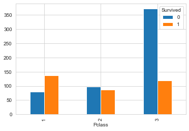

```python
pd.crosstab(titanic['Pclass'],titanic['Survived']).plot(kind='bar')
```

The Chart confirms 1st class more likely survivied than other classes

The Chart also confirms 3rd class more likely dead than other classes

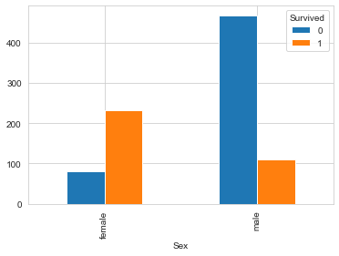

```python
pd.crosstab(titanic['Sex'],titanic['Survived']).plot(kind='bar')
```

Through the above chart this is confirm that Women more likely survivied than Men

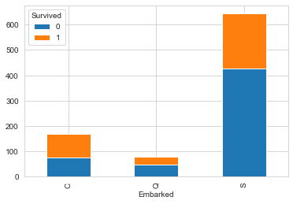

```python
pd.crosstab(titanic['Embarked'],titanic['Survived']).plot(kind='bar',stacked=True)
# Stacked is used for stacked graph
```

The Chart confirms a person aboarded from C slightly more likely survived

The Chart also confirms a person aboarded from Q & S more likely dead

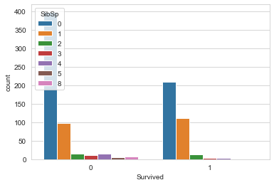

```python
sns.countplot(hue='SibSp', x='Survived',data=titanic)
# hue is used for colour appearance parameter
```

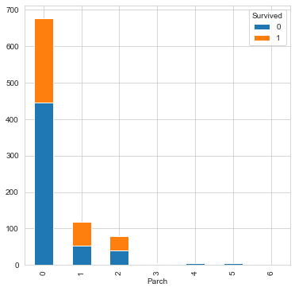

```python
pd.crosstab(titanic['Parch'],titanic['Survived']).plot(kind='bar',stacked=True,figsize=(6,6))
```

- The Chart confirms a person aboarded with parents or children more likely survived
- The Chart confirms **a person aboarded alone** more likely dead

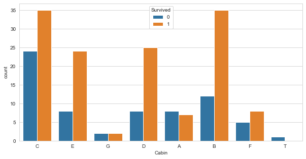

```python
plt.figure (figsize=(10,5))
sns.countplot(x='Cabin',hue='Survived',data=titanic)
```

###### TWO WAY TABLE

```python
titanic.groupby(['Sex','Pclass','Embarked','Survived'],axis=0).size()
# 0 for rows
# by default axis=0
```

```
Sex     Pclass  Embarked  Survived
female  1       C         0             1
                          1            42
                Q         1             1
                S         0             2
                          1            46
        2       C         1             7
                Q         1             2
                S         0             6
                          1            61
        3       C         0             8
                          1            15
                Q         0             9
                          1            24
                S         0            55
                          1            33
male    1       C         0            25
                          1            17
                Q         0             1
                S         0            51
                          1            28
        2       C         0             8
                          1             2
                Q         0             1
                S         0            82
                          1            15
        3       C         0            33
                          1            10
                Q         0            36
                          1             3
                S         0           231
                          1            34
dtype: int64
```

```python
counts = titanic.groupby(['Pclass', 'Sex'])
counts.size()
```

```
Pclass  Sex
1       female     94
        male      122
2       female     76
        male      108
3       female    144
        male      347
dtype: int64
```

```python
pd.crosstab([titanic.Sex,titanic.Survived],titanic.Pclass,margins=True).style.background_gradient(cmap='summer_r')
```

| Sex | Pclass Survived | 1 | 2 | 3 | All |
| --- | --- | --- | --- | --- | --- |
| female | 0 | 3 | 6 | 72 | 81 |
|  | 1 | 91 | 70 | 72 | 233 |
| male | 0 | 77 | 91 | 300 | 468 |
|  | 1 | 45 | 17 | 47 | 109 |
| All |  | 216 | 184 | 491 | 891 |

## CHI SQUARE TEST

Null Hypothesis : There is no relationship b/w 2 categorical variables

Alternate Hypothesis: There is a relationship b/w the categorical variables

```python
titanic['Sex'].value_counts()
```

```
male      577
female    314
Name: Sex, dtype: int64
```

```python
tit=pd.crosstab(index=titanic['Sex'],columns=titanic['Survived'])
tit
```

| Survived Sex | 0 | 1 |
| --- | --- | --- |
| female | 81 | 233 |
| male | 468 | 109 |

```python
tit.iloc[0].values
```

```
array([ 81, 233], dtype=int64)
```

```python
from scipy import stats
(chi2,p,dof,_)=stats.chi2_contingency([tit.iloc[0].values,tit.iloc[1].values])
```

```python
print('chi2   :', chi2)
print('p-value  :', round(p, 5))
print('degree of freedom :',dof)
```

```
chi2   : 260.71702016732104
p-value  : 0.0
degree of freedom : 1
```

** chi2=sum((Observed-Expected)^2/Expected)

```python
pd.crosstab(index=titanic['Sex'],columns=titanic['Survived'],margins=True)
# observed values
```

| Survived Sex | 0 | 1 | All |
| --- | --- | --- | --- |
| female | 81 | 233 | 314 |
| male | 468 | 109 | 577 |
| All | 549 | 342 | 891 |

p-value is less than 0.05 so as per the standard practice we'll reject the null hypothesis, thus there is significant relationship b/w these variables - Sex & Survivved

### Continuous & Categorical

CATPLOT - It shows the relationship between a numerical and one or more categorical variables using one of several visual representations. The `kind` parameter selects the underlying axes-level function to use:

Categorical Plots Like - POINT (FACTORPLOT), STRIP (CATPLOT), SWARM, BOX, VIOLIN, BOXEN, BAR, COUNT)

HEIGHT AND ASPECT ARE USED FOR PLOT SIZE

CATPLOT -

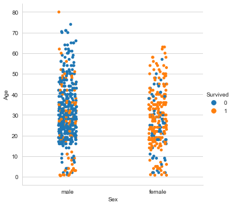

```python
sns.catplot(x='Sex',y='Age',hue='Survived',data=titanic)
```

SWARM PLOT - GROUPED PLOT (ATLEAST ONE AXIS SHOULD BE NUMERIC)

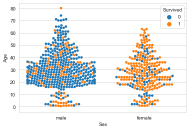

```python
sns.swarmplot(x='Sex',y='Age',hue='Survived',data=titanic)
```

As per the above plot it shows that the age of most passengers are b/w 20-40.

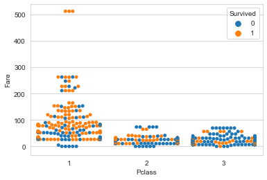

```python
sns.swarmplot(x='Pclass',y='Fare',hue='Survived',data=titanic)
```

The plot shows that the fare of most passengers are below 100.

The plot shows that the most of the passengers servived who paid more than 100 and all of them belong to the first class.

VIOLIN PLOT - LOOKS LIKE VIOLIN (ATLEAST ONE AXIS SHOULD BE NUMERIC)

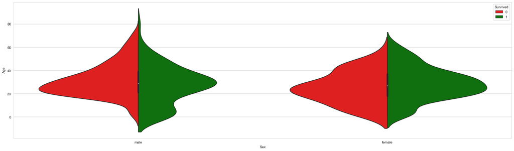

```python
fig=plt.figure(figsize=(25,7))
sns.violinplot(x='Sex',y='Age',hue='Survived',data=titanic,split=True,palette={0:'r',1:'g'})
# palette may be coolwarm also
```

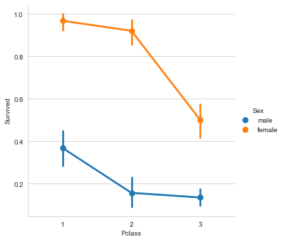

```python
sns.factorplot(x='Pclass',y='Survived',hue='Sex',data=titanic)
```

## Step 4: Missing Values Treatment

1.As we have already noticed that there are missing values in dataset.

2.Missing Data will not make any impact on the result if its percentage is less than 1%, if missing data’s range within the range of 1-5% then it is somehow manageable; however in case of 5-15% complex techniques are used for handling the problems of missing data but if it exceeds from 15% then it will surely hinder the result achieved after applying data mining techniques

3.Handling such values is very important as this could lead to wrong results

4.Missing values could occur due to several reasons like,

a. – During data extraction i.e. while fetching the data required for the analysis

b. – During data collection itself there could be some fields for which the values may not have been collected.

5.But there are ways to handle these problems

```python
# null values in the data set
titanic.isnull().values.any()
```

```
True
```

```python
titanic.isnull().sum()
```

```
PassengerId      0
Survived         0
Pclass           0
Name             0
Sex              0
Age            177
SibSp            0
Parch            0
Ticket           0
Fare             0
Cabin          687
Embarked         2
dtype: int64
```

```python
titanic.isnull().sum()*100 / len(titanic)
# Percentage of missing values
```

```
PassengerId     0.000000
Survived        0.000000
Pclass          0.000000
Name            0.000000
Sex             0.000000
Age            19.865320
SibSp           0.000000
Parch           0.000000
Ticket          0.000000
Fare            0.000000
Cabin          77.104377
Embarked        0.224467
dtype: float64
```

#### 1. Deletion: Deleting observations or variables.

If a particular variable is having more missing values than rest of the variables in the dataset, then we are better off without that variable unless it is a really important predictor that makes a lot of business sense.

Also, if in a huge dataset we have very minute number of observations missing, then we can delete the whole of observations altogether.

#### 2. Single Imputation: In single imputation, we use mean, median or mode.

If the variable is numeric then replace the missing values with either mean, median or mode.

If the variable is otherwise generally normally distributed (and in particular does not have any skewness), we would choose mean.

If the data skewed, median imputation is suggested.

If the variable is categorical then we could replace the missing values with the most frequent occurring value in that variable, i.e the mode.

We use the fillna function of pandas to replace na values with the value of our interest and inplace=True command makes the permanently changes the value in that dataframe

#### dataframe.['col_name'].fillna(0, inplace=True)

We can see that there are 3 missing variables-Age, Cabin & Embarked. we need to find a way to replace the missing values

Looking at the histogram of the variable Age (non missing value, we see that it is positively skewed. Hence we can impute missing values with Median of nonmissing data

#### Constant:

This choice allows us to provide our own default value to fill in the gaps. This might be an integer or real number for numeric variables, or else a special marker or the choice of something other than the majority category for Categorical variables.

#### Closest fit:

The closest fit algorithm depends upon exchanging absent values with present value of the similar attribute of other likewise cases. Main notion is to find out from dataset likewise scenarios and select the likewise case to the case in discussion with missing attribute values. This method is more useful for a small dataset

#### FILLING OF MISSING VALUES IN AGE COLUMN

As we have already seen by the box plot that there are outliers in Age and survival highly depends on age factor, so we'll fill the missing values by the median of age in respect of sex

```python
titanic.groupby('Sex')['Age'].median()
```

```
Sex
female    27.0
male      29.0
Name: Age, dtype: float64
```

```python
titanic['Age']=titanic['Age'].fillna(titanic.groupby('Sex')['Age'].transform('median'))
```

#### FILLING OF MISSING VALUES IN EMBARKED COLUMN

Embarked data is categorical, so we'll fill the missing value by the most frequent value i.e. mode

```python
titanic['Embarked'].describe()
```

```
count     889
unique      3
top         S
freq      644
Name: Embarked, dtype: object
```

```python
titanic['Embarked'].mode()[0]
# or titanic['Embarked'].mode().iloc[0]
```

```
'S'
```

```python
titanic['Embarked']=titanic['Embarked'].fillna(titanic['Embarked'].mode()[0])
```

#### FILLING OF MISSING VALUES IN CABIN COLUMN

As we know by our previous observation that there is a major role of Pclass in passengers survival,so we'll replace the missing values with mode of each passenger class

```python
titanic['Cabin'].unique()
```

```
array([nan, 'C', 'E', 'G', 'D', 'A', 'B', 'F', 'T'], dtype=object)
```

```python
titanic['Cabin'].describe()
```

```
count     204
unique      8
top         C
freq       59
Name: Cabin, dtype: object
```

```python
titanic.groupby('Pclass')['Cabin'].describe()
```

| Pclass | count | unique | top | freq |
| --- | --- | --- | --- | --- |
| 1 | 176 | 6 | C | 59 |
| 2 | 16 | 3 | F | 8 |
| 3 | 12 | 3 | F | 5 |

```python
def impute_Cabin(cols):
    Cabin=cols[0]
    Pclass=cols[1]

    if pd.isnull(Cabin):
        if Pclass==1:
            return 'C'
        elif Pclass==2:
            return 'F'
        else:
            return 'F'
    else:
        return Cabin
```

```python
titanic['Cabin']=titanic[['Cabin','Pclass']].apply(impute_Cabin,axis=1)
```

```python
titanic.isnull().sum()
```

```
PassengerId    0
Survived       0
Pclass         0
Name           0
Sex            0
Age            0
SibSp          0
Parch          0
Ticket         0
Fare           0
Cabin          0
Embarked       0
dtype: int64
```

It can be clearly seen that after applying the above mentioned techniques there is no missing value in dataset. Now we'll proceed for the next step of EDA i.e. outliers detection & treatment.

## Step 5: Outliers

#### What is an Outlier?

1.Outlier is an observation that appears far away and diverges from an overall pattern in a sample.

2.Outliers can drastically change the results of the data analysis and statistical modeling. There are numerous unfavorable impacts of outliers in the data set:

a. It increases the error variance and reduces the power of statistical tests

b. If the outliers are non-randomly distributed, they can decrease normality

c. They can bias or influence estimates that may be of substantive interest

#### Causes of Outliers:

1.Data Entry Errors - Human errors such as errors caused during data collection, recording, or entry can cause outliers in data.

2.Measurement Error - When the measurement instrument used turns out to be faulty.

3.Intentional Error - This is commonly found in self-reported measures that involves sensitive data.

4.Data Processing Error - When data is collected from different sources

5.Sampling Error - Data considered which is not part of the sample

6.Natural Outlier - When an outlier is not artificial (due to error), it is a natural outlier.

#### Outlier Detection

1.Outliers can be detected using boxplots and scatter plots

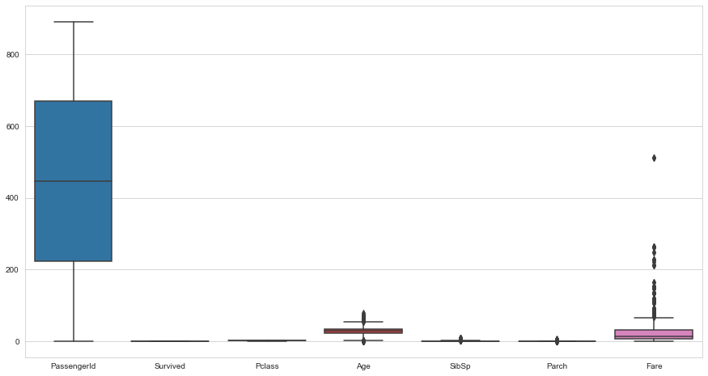

```python
plt.figure(figsize=(15,8))
sns.boxplot(data=titanic)
```

#### Other than the plots, Outliers can also be detected by using certain thumb rules,

1.– Any value, which is below the range of Q1-1.5x IQR and above the range of Q3+1.5 x IQR where IQR = Q3-Q1

2.– Any value which out of range of 5th and 95th percentile can be considered as outlier

3.– Data points, three or more standard deviation away from mean are considered outlier

```python
titanic['Fare'].describe()
```

```
count    891.000000
mean      32.204208
std       49.693429
min        0.000000
25%        7.910400
50%       14.454200
75%       31.000000
max      512.329200
Name: Fare, dtype: float64
```

```python
IQR = titanic['Fare'].quantile(0.75)-titanic['Fare'].quantile(0.25)
print(IQR)
```

```
23.0896
```

```python
Upper_OutlierLimit = titanic['Fare'].quantile(0.75) + 1.5*IQR
Lower_OutlierLimit = titanic['Fare'].quantile(0.25) - 1.5*IQR

print(Upper_OutlierLimit)
print(Lower_OutlierLimit)
```

```
65.6344
-26.724
```

```python
OutlierValues = titanic[(titanic['Fare']>=Upper_OutlierLimit) | (titanic['Fare']<=Lower_OutlierLimit)]
```

```python
OutlierValues
```

|  | PassengerId | Survived | Pclass | Name | Sex | Age | SibSp | Parch | Ticket | Fare | Cabin | Embarked |
| --- | --- | --- | --- | --- | --- | --- | --- | --- | --- | --- | --- | --- |
| 1 | 2 | 1 | 1 | Cumings, Mrs. John Bradley (Florence Briggs Th... | female | 38.0 | 1 | 0 | PC 17599 | 71.2833 | C | C |
| 27 | 28 | 0 | 1 | Fortune, Mr. Charles Alexander | male | 19.0 | 3 | 2 | 19950 | 263.0000 | C | S |
| 31 | 32 | 1 | 1 | Spencer, Mrs. William Augustus (Marie Eugenie) | female | 27.0 | 1 | 0 | PC 17569 | 146.5208 | B | C |
| 34 | 35 | 0 | 1 | Meyer, Mr. Edgar Joseph | male | 28.0 | 1 | 0 | PC 17604 | 82.1708 | C | C |
| 52 | 53 | 1 | 1 | Harper, Mrs. Henry Sleeper (Myna Haxtun) | female | 49.0 | 1 | 0 | PC 17572 | 76.7292 | D | C |
| ... | ... | ... | ... | ... | ... | ... | ... | ... | ... | ... | ... | ... |
| 846 | 847 | 0 | 3 | Sage, Mr. Douglas Bullen | male | 29.0 | 8 | 2 | CA. 2343 | 69.5500 | F | S |
| 849 | 850 | 1 | 1 | Goldenberg, Mrs. Samuel L (Edwiga Grabowska) | female | 27.0 | 1 | 0 | 17453 | 89.1042 | C | C |
| 856 | 857 | 1 | 1 | Wick, Mrs. George Dennick (Mary Hitchcock) | female | 45.0 | 1 | 1 | 36928 | 164.8667 | C | S |
| 863 | 864 | 0 | 3 | Sage, Miss. Dorothy Edith "Dolly" | female | 27.0 | 8 | 2 | CA. 2343 | 69.5500 | F | S |
| 879 | 880 | 1 | 1 | Potter, Mrs. Thomas Jr (Lily Alexenia Wilson) | female | 56.0 | 0 | 1 | 11767 | 83.1583 | C | C |

116 rows × 12 columns

#### Handle Outliers

1.We could remove the outliers from the data if they are due to data entry or data processing errors

2.Based on business understanding you could also replace the outliers with mean or median

3.If there is a pattern of interest in the outliers then they could be handled separately. For example if the outliers are like in groups then treat both groups as two different groups and build individual model for both groups and then combine the output

4.Also the outliers can be capped with 5th or 95th percentile

We will be using capping method for imputation of the outlier in our data for variable Fare

```python
titanic['Fare'][(titanic['Fare']>=Upper_OutlierLimit) | (titanic['Fare']<=Lower_OutlierLimit)]=titanic['Fare'].quantile(0.85)
```

There was still one outlier in the Fare when I was capping at 95th Quantile, so I reduced capping from 95th to 85th to remove the outliers.

There are Upper and lower both kinds of outliers in Age, so we will treat them seperately. Capping for upper outliers (0.95) and for lower outliers (0.05)

```python
IQR_Age = titanic['Age'].quantile(0.75)-titanic['Age'].quantile(0.25)
print(IQR_Age)
Upper_OutlierLimit_Age = titanic['Age'].quantile(0.75) + 1.5*IQR_Age
Lower_OutlierLimit_Age = titanic['Age'].quantile(0.25) - 1.5*IQR_Age
print(Upper_OutlierLimit_Age)
print(Lower_OutlierLimit_Age)
OutlierValues_Age = titanic[(titanic['Age']>=Upper_OutlierLimit_Age) | (titanic['Age']<=Lower_OutlierLimit_Age)]
titanic['Age'][(titanic['Age']>=Upper_OutlierLimit_Age)]=titanic['Age'].quantile(0.95)
titanic['Age'][(titanic['Age']<=Lower_OutlierLimit_Age)]=titanic['Age'].quantile(0.05)
```

```
13.0
54.5
2.5
```

```python
IQR_SibSp = titanic['SibSp'].quantile(0.75)-titanic['SibSp'].quantile(0.25)
print(IQR_SibSp)
Upper_OutlierLimit_SibSp = titanic['SibSp'].quantile(0.75) + 1.5*IQR_SibSp
Lower_OutlierLimit_SibSp = titanic['SibSp'].quantile(0.25) - 1.5*IQR_SibSp
print(Upper_OutlierLimit_SibSp)
print(Lower_OutlierLimit_SibSp)
OutlierValues_SibSp = titanic[(titanic['SibSp']>=Upper_OutlierLimit_SibSp) | (titanic['SibSp']<=Lower_OutlierLimit_SibSp)]
titanic['SibSp'][(titanic['SibSp']>=Upper_OutlierLimit_SibSp)|(titanic['SibSp']<=Lower_OutlierLimit_SibSp)]=titanic['SibSp'].quantile(0.9)
```

```
1.0
2.5
-1.5
```

```python
IQR_Parch = titanic['Parch'].quantile(0.75)-titanic['Parch'].quantile(0.25)
print(IQR_Parch)
Upper_OutlierLimit_Parch = titanic['Parch'].quantile(0.75) + 1.5*IQR_Parch
Lower_OutlierLimit_Parch = titanic['Parch'].quantile(0.25) - 1.5*IQR_Parch
print(Upper_OutlierLimit_Parch)
print(Lower_OutlierLimit_Parch)
OutlierValues_Parch = titanic[(titanic['Parch']>=Upper_OutlierLimit_Parch) | (titanic['Parch']<=Lower_OutlierLimit_Parch)]
titanic['Parch'][(titanic['Parch']>=Upper_OutlierLimit_Parch)|(titanic['Parch']<=Lower_OutlierLimit_Parch)]=titanic['Parch'].quantile(0.95)
```

```
0.0
0.0
0.0
```

#### BOX PLOTS AFTER CAPPING

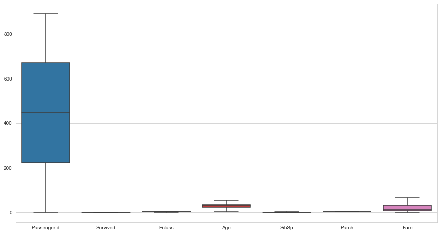

```python
plt.figure(figsize=(15,8))
sns.boxplot(data=titanic)
```

As per the above graph it could be clearly seen that all the outliers are treated.

## Step 6: Feature Engineering - Variable Transformation and Dummy Variable Creation

1.Variable creation is a process to generate a new variables / features based on existing variable(s)

2.Dummy coding provides one way of using categorical predictor variables in various kinds of estimation models such as linear regression. Dummy coding uses only ones and zeros to convey all of the necessary information on group membership.

```python
titanic.dtypes
```

```
PassengerId      int64
Survived         int64
Pclass           int64
Name            object
Sex             object
Age            float64
SibSp            int64
Parch            int64
Ticket          object
Fare           float64
Cabin           object
Embarked        object
dtype: object
```

Since,'Name', 'Sex', 'Ticket', 'Cabin', 'Embarked' are categorical variables, we need to convert them into dummy variables so that we will be able to use them as a predictor

We'll remove the features(name, passengerid & ticket) bcz these do not have impact on our ML project

```python
del titanic['Name']
```

```python
titanic.drop(['PassengerId','Ticket'],axis=1,inplace=True)
```

```python
# TO CONVERT ALL OBJECTS OF DATA SET INTO DUMMIES
titanic_data=pd.get_dummies(titanic,drop_first=True)
```

```python
titanic_data.head()
```

|  | Survived | Pclass | Age | SibSp | Parch | Fare | Sex_male | Cabin_B | Cabin_C | Cabin_D | Cabin_E | Cabin_F | Cabin_G | Cabin_T | Embarked_Q | Embarked_S |
| --- | --- | --- | --- | --- | --- | --- | --- | --- | --- | --- | --- | --- | --- | --- | --- | --- |
| 0 | 0 | 3 | 22.0 | 1 | 2 | 7.2500 | 1 | 0 | 0 | 0 | 0 | 1 | 0 | 0 | 0 | 1 |
| 1 | 1 | 1 | 38.0 | 1 | 2 | 56.4958 | 0 | 0 | 1 | 0 | 0 | 0 | 0 | 0 | 0 | 0 |
| 2 | 1 | 3 | 26.0 | 0 | 2 | 7.9250 | 0 | 0 | 0 | 0 | 0 | 1 | 0 | 0 | 0 | 1 |
| 3 | 1 | 1 | 35.0 | 1 | 2 | 53.1000 | 0 | 0 | 1 | 0 | 0 | 0 | 0 | 0 | 0 | 1 |
| 4 | 0 | 3 | 35.0 | 0 | 2 | 8.0500 | 1 | 0 | 0 | 0 | 0 | 1 | 0 | 0 | 0 | 1 |

We'll also convert the Pclass into dummies

```python
pclass=pd.get_dummies(titanic['Pclass'],drop_first=True,prefix='Pclass')
```

#### FamilySize feature

•Family Size = Siblings+spouse+parents+childs+you

•Family Size = SibSp+Parch+1

Now we'll create the new feature "FamilySize" by using two features "SibSp" and "Parch"..

```python
titanic["FamilySize"] = titanic["SibSp"] + titanic["Parch"] + 1
```

```python
titanic['FamilySize'].unique()
```

```
array([4, 3, 5], dtype=int64)
```

```python
familysize=pd.get_dummies(titanic['FamilySize'],drop_first=True,prefix='FamilySize')
```

```python
Titanic=pd.concat([titanic_data,pclass,familysize], axis=1)
Titanic.head()
```

|  | Survived | Pclass | Age | SibSp | Parch | Fare | Sex_male | Cabin_B | Cabin_C | Cabin_D | Cabin_E | Cabin_F | Cabin_G | Cabin_T | Embarked_Q | Embarked_S | Pclass_2 | Pclass_3 | FamilySize_4 | FamilySize_5 |
| --- | --- | --- | --- | --- | --- | --- | --- | --- | --- | --- | --- | --- | --- | --- | --- | --- | --- | --- | --- | --- |
| 0 | 0 | 3 | 22.0 | 1 | 2 | 7.2500 | 1 | 0 | 0 | 0 | 0 | 1 | 0 | 0 | 0 | 1 | 0 | 1 | 1 | 0 |
| 1 | 1 | 1 | 38.0 | 1 | 2 | 56.4958 | 0 | 0 | 1 | 0 | 0 | 0 | 0 | 0 | 0 | 0 | 0 | 0 | 1 | 0 |
| 2 | 1 | 3 | 26.0 | 0 | 2 | 7.9250 | 0 | 0 | 0 | 0 | 0 | 1 | 0 | 0 | 0 | 1 | 0 | 1 | 0 | 0 |
| 3 | 1 | 1 | 35.0 | 1 | 2 | 53.1000 | 0 | 0 | 1 | 0 | 0 | 0 | 0 | 0 | 0 | 1 | 0 | 0 | 1 | 0 |
| 4 | 0 | 3 | 35.0 | 0 | 2 | 8.0500 | 1 | 0 | 0 | 0 | 0 | 1 | 0 | 0 | 0 | 1 | 0 | 1 | 0 | 0 |

We have already created new features by using SibSp, Parch & Pclass, so we'll drop all these. Now after deleting these features our datset is ready to apply ML techniques

```python
Titanic.drop(['SibSp','Parch','Pclass'],axis=1,inplace=True)
```

# Building Machine Learning Models

Now we will train several Machine Learning models and compare their results.

```python
Titanic.head()
```

|  | Survived | Age | Fare | Sex_male | Cabin_B | Cabin_C | Cabin_D | Cabin_E | Cabin_F | Cabin_G | Cabin_T | Embarked_Q | Embarked_S | Pclass_2 | Pclass_3 | FamilySize_4 | FamilySize_5 |
| --- | --- | --- | --- | --- | --- | --- | --- | --- | --- | --- | --- | --- | --- | --- | --- | --- | --- |
| 0 | 0 | 22.0 | 7.2500 | 1 | 0 | 0 | 0 | 0 | 1 | 0 | 0 | 0 | 1 | 0 | 1 | 1 | 0 |
| 1 | 1 | 38.0 | 56.4958 | 0 | 0 | 1 | 0 | 0 | 0 | 0 | 0 | 0 | 0 | 0 | 0 | 1 | 0 |
| 2 | 1 | 26.0 | 7.9250 | 0 | 0 | 0 | 0 | 0 | 1 | 0 | 0 | 0 | 1 | 0 | 1 | 0 | 0 |
| 3 | 1 | 35.0 | 53.1000 | 0 | 0 | 1 | 0 | 0 | 0 | 0 | 0 | 0 | 1 | 0 | 0 | 1 | 0 |
| 4 | 0 | 35.0 | 8.0500 | 1 | 0 | 0 | 0 | 0 | 1 | 0 | 0 | 0 | 1 | 0 | 1 | 0 | 0 |

## STEP 1: DEFINE VARIABLES X AND Y

```python
X=Titanic.iloc[:,1:].values
X.shape
# values convert into array
# vector is one dimensional
```

```
(891, 16)
```

```python
y=Titanic.iloc[:,0].values
y.shape
```

```
(891,)
```

## STEP 2: SPLIT THE MODEL

```python
from sklearn.model_selection import train_test_split
```

```python
X_train,X_test,y_train,y_test=train_test_split(X,y,test_size=0.25,random_state=0)
```

Test size is generally considered b/w 20 to 33%

Test size is directly proportional to accuracy

random_state=0, so that the result may not change each time we run the code.

## FINDING THE BEST MODEL-

```python
# Algorithms
from sklearn import linear_model
from sklearn.linear_model import LogisticRegression
from sklearn.ensemble import RandomForestClassifier
from sklearn.tree import DecisionTreeClassifier
from sklearn.neighbors import KNeighborsClassifier
from sklearn.svm import SVC
from sklearn.naive_bayes import GaussianNB
from sklearn.model_selection import cross_val_score
```

```python
# Spot Check Algorithms
models = []
models.append(('LR', LogisticRegression(random_state=0)))
models.append(('RF', RandomForestClassifier(random_state=0)))
models.append(('KNN', KNeighborsClassifier()))
models.append(('DT', DecisionTreeClassifier(random_state=0)))
models.append(('NB', GaussianNB()))
models.append(('SVM', SVC(random_state=0)))
# evaluate each model in turn
results = []
names = []
for name, model in models:
    cv_results = cross_val_score(model, X_train, y_train, cv=10, scoring='accuracy')
    results.append(cv_results)
    names.append(name)
    print('%s: %f (%f)' % (name, cv_results.mean(), cv_results.std()))
```

```
LR: 0.790525 (0.044357)
RF: 0.821958 (0.052118)
KNN: 0.711262 (0.071632)
DT: 0.768046 (0.056034)
NB: 0.670669 (0.105502)
SVM: 0.660244 (0.027585)
```

As we can see, the Random Forest classifier goes on the first place.

Our model has an average accuracy of 82.19 % with a standard deviation of 5.21 %. The standard deviation shows us, how precise the estimates are .

This means in our case that the accuracy of our model can differ + — 5.21 %.

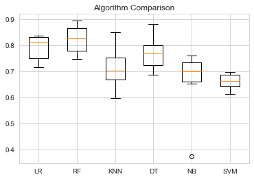

```python
# Compare Algorithms
plt.boxplot(results, labels=names)
plt.title('Algorithm Comparison')
plt.show()
```

## STEP3: BUILT THE MODEL

```python
rfc = RandomForestClassifier(random_state=0)
rfc.fit(X_train, y_train)
```

```
RandomForestClassifier(bootstrap=True, ccp_alpha=0.0, class_weight=None,
                       criterion='gini', max_depth=None, max_features='auto',
                       max_leaf_nodes=None, max_samples=None,
                       min_impurity_decrease=0.0, min_impurity_split=None,
                       min_samples_leaf=1, min_samples_split=2,
                       min_weight_fraction_leaf=0.0, n_estimators=100,
                       n_jobs=None, oob_score=False, random_state=0, verbose=0,
                       warm_start=False)
```

## STEP4: PREDICT THE MODEL

```python
y_pred = rfc.predict(X_test)
y_pred
```

```
array([0, 0, 0, 1, 0, 0, 1, 1, 1, 1, 0, 0, 0, 1, 1, 0, 0, 0, 0, 0, 0, 1,
       0, 0, 0, 1, 0, 1, 1, 0, 0, 1, 0, 0, 0, 0, 0, 0, 0, 0, 0, 0, 0, 0,
       1, 0, 0, 1, 0, 0, 0, 0, 1, 0, 0, 0, 0, 0, 0, 0, 0, 0, 1, 0, 0, 0,
       1, 0, 1, 1, 1, 0, 0, 0, 0, 1, 0, 0, 0, 1, 0, 0, 1, 0, 0, 1, 1, 0,
       1, 1, 0, 0, 1, 1, 0, 0, 1, 0, 0, 0, 0, 0, 0, 0, 1, 1, 1, 0, 0, 1,
       0, 1, 1, 0, 1, 1, 0, 1, 0, 1, 1, 0, 0, 0, 0, 0, 0, 0, 0, 0, 1, 0,
       0, 1, 0, 0, 0, 0, 0, 0, 0, 1, 0, 1, 1, 0, 0, 1, 1, 1, 1, 0, 1, 0,
       1, 0, 0, 0, 1, 1, 0, 0, 1, 1, 0, 0, 0, 0, 0, 0, 0, 1, 0, 0, 1, 0,
       1, 0, 0, 1, 0, 0, 0, 0, 1, 0, 1, 0, 0, 1, 1, 1, 1, 1, 0, 0, 0, 1,
       1, 0, 0, 0, 0, 0, 0, 0, 1, 0, 1, 0, 0, 0, 0, 1, 0, 0, 0, 0, 0, 1,
       0, 1, 1], dtype=int64)
```

## STEP 5: EVALUATE THE MODEL

```python
from sklearn import metrics
```

```python
metrics.confusion_matrix(y_test,y_pred)
```

```
array([[122,  17],
       [ 26,  58]], dtype=int64)
```

```python
pd.crosstab(y_test,y_pred,rownames=['Actual'],colnames=['Predicted'])
```

| Predicted Actual | 0 | 1 |
| --- | --- | --- |
| 0 | 122 | 17 |
| 1 | 26 | 58 |

```python
metrics.accuracy_score(y_test,y_pred)
```

```
0.8071748878923767
```

```python
metrics.precision_score(y_test,y_pred)
```

```
0.7733333333333333
```

```python
metrics.recall_score(y_test,y_pred)
```

```
0.6904761904761905
```

Our model predicts 77% of the time, a passengers survival correctly (precision). The recall tells us that it predicted the survival of 69 % of the people who actually survived.

```python
metrics.f1_score(y_test,y_pred)
```

```
0.729559748427673
```

We can combine precision and recall into one score, which is called the F-score. The F-score is computed with the harmonic mean of precision and recall. Note that it assigns much more weight to low values. As a result of that, the classifier will only get a high F-score, if both recall and precision are high.

There we have it, a 72.95 % F-score. The score is not that high, because we have a recall of 69%. But unfortunately the F-score is not perfect, because it favors classifiers that have a similar precision and recall. This is a problem, because we sometimes want a high precision and sometimes a high recall. The thing is that an increasing precision, sometimes results in an decreasing recall and vice versa (depending on the threshold). This is called the precision/recall tradeoff.

```python
cf=metrics.classification_report(y_test,y_pred)
print(cf)
```

```
              precision    recall  f1-score   support

           0       0.82      0.88      0.85       139
           1       0.77      0.69      0.73        84

    accuracy                           0.81       223
   macro avg       0.80      0.78      0.79       223
weighted avg       0.81      0.81      0.80       223
```

```python
# getting the probabilities of our predictions
y_prob = rfc.predict_proba(X_test)
```

```python
y_prob = y_prob[:,1]
```

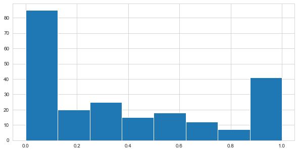

```python
plt.figure(figsize=(10,5))
plt.hist(y_prob,bins=8)
```

# Precision Recall Curve

For each person the Random Forest algorithm has to classify, it computes a probability based on a function and it classifies the person as survived (when the score is bigger than threshold) or as not survived (when the score is smaller than the threshold). That’s why the threshold plays an important part.

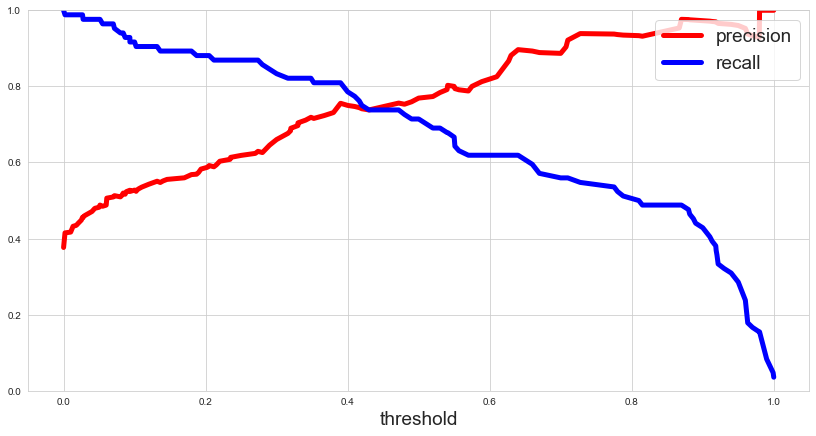

```python
from sklearn.metrics import precision_recall_curve
precision, recall, threshold = precision_recall_curve(y_test, y_prob)
def plot_precision_and_recall(precision, recall, threshold):
    plt.plot(threshold, precision[:-1], "r-", label="precision", linewidth=5)
    plt.plot(threshold, recall[:-1], "b", label="recall", linewidth=5)
    plt.xlabel("threshold", fontsize=19)
    plt.legend(loc="upper right", fontsize=19)
    plt.ylim([0, 1])

plt.figure(figsize=(14, 7))
plot_precision_and_recall(precision, recall, threshold)
plt.show()
```

Above we can clearly see that the recall is falling of rapidly at a precision of around 80%. Because of that we may want to select the precision/recall tradeoff before that — maybe at around 70 %.

We are now able to choose a threshold, that gives us the best precision/recall tradeoff for our current machine learning problem. If we want for example a precision of 75%, we can easily look at the plots and see that we would need a threshold of around 0.4. Then we could train a model with exactly that threshold and would get the desired accuracy.

[figure not shown]

```python
def plot_precision_vs_recall(precision, recall):
    plt.plot(recall, precision, "g--", linewidth=2.5)
    plt.ylabel("recall", fontsize=19)
    plt.xlabel("precision", fontsize=19)
    plt.axis([0, 1.5, 0, 1.5])

plt.figure(figsize=(14, 7))
plot_precision_vs_recall(precision, recall)
plt.show()
```

# ROC AUC Curve

Another way to evaluate and compare your binary classifier is provided by the ROC AUC Curve. This curve plots the true positive rate (also called recall) against the false positive rate (ratio of incorrectly classified negative instances), instead of plotting the precision versus the recall.

```python
from sklearn.metrics import roc_auc_score, roc_curve, auc, accuracy_score
```

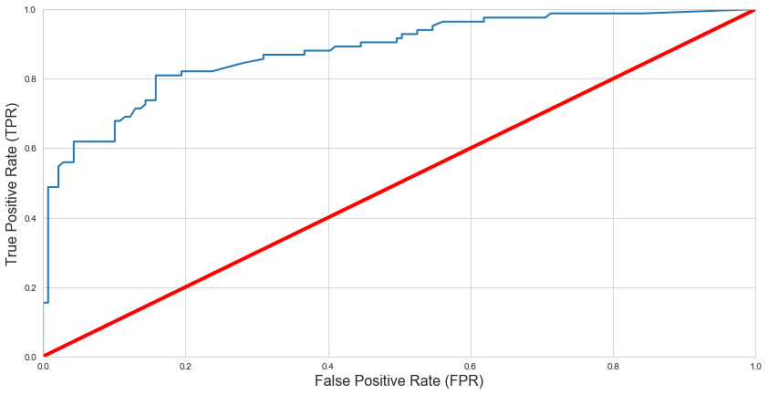

```python
# compute true positive rate and false positive rate
fpr, tpr, thresholds = roc_curve(y_test, y_prob)
# plotting them against each other
def plot_roc_curve(fpr,tpr, label=None):
    plt.plot(fpr,tpr, linewidth=2, label=label)
    plt.plot([0, 1], [0, 1], 'r', linewidth=4)
    plt.axis([0, 1, 0, 1])
    plt.xlabel('False Positive Rate (FPR)', fontsize=16)
    plt.ylabel('True Positive Rate (TPR)', fontsize=16)

plt.figure(figsize=(14, 7))
plot_roc_curve(fpr,tpr)
plt.show()
```

The red line in the middel represents a purely random classifier (e.g a coin flip) and therefore our classifier should be as far away from it as possible. Our Random Forest model seems to do a good job.

Of course we also have a tradeoff here, because the classifier produces more false positives, the higher the true positive rate is.

# ROC AUC Score

The ROC AUC Score is the corresponding score to the ROC AUC Curve. It is simply computed by measuring the area under the curve, which is called AUC.

A classifiers that is 100% correct, would have a ROC AUC Score of 1 and a completely random classiffier would have a score of 0.5.

```python
roc_auc = auc(fpr, tpr)
roc_auc
```

```
0.8802243919150394
```